# Report on Portfolio Expertise

Portugal

```
Portugal
     532
```

# I. Level A: within and across each dimension

## Academic expertise

#### Figure A1: Level of education and relation to portfolio

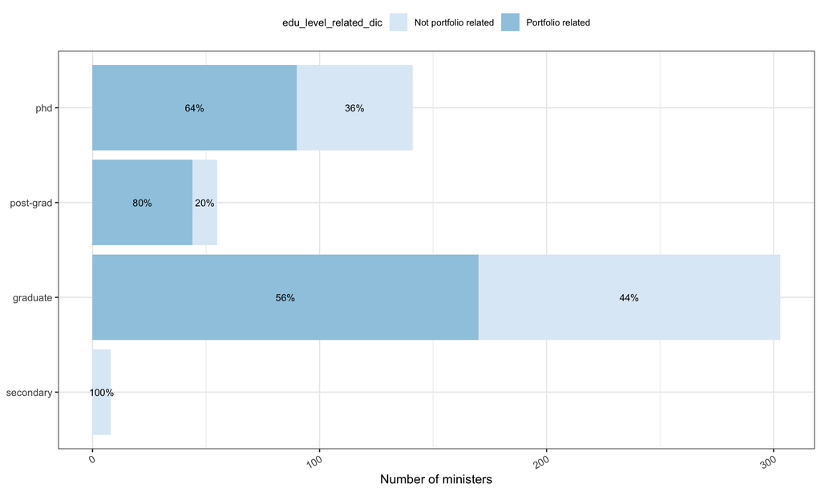

*Figure A1. Level of education and relation to portfolio (Portugal, ministerial appointments, N=507).*

General pattern: Nearly all ministers hold at least a graduate-level degree (499/507, 98.4%). Within this group, PhD holders account for 27.8% of all ministers (141/507), postgraduate (non-PhD) degree holders for 10.8% (55/507), and graduate-only degree holders for the remaining 59.8% (303/507). Only 1.6% (8/507) reached secondary education alone, and no minister shows primary, non-university higher, or no formal education. This matches the standard finding in the literature, which typically stops at this level of description (“ministers are highly credentialed”).

With portfolio relation: Overall, only 60.0% of ministers (304/507) hold an educational background related to their portfolio; the remaining 40.0% do not, despite the near-universal presence of graduate-level credentials. Relatedness is not monotonic with educational level: it is highest among postgraduate (non-PhD) degree holders (80.0%, 44/55), intermediate among PhD holders (63.8%, 90/141), and lowest among graduate-only degree holders (56.1%, 170/303). All 8 ministers with secondary education alone show no portfolio relation. This is the first indication, still at the raw-indicator level, that credential level alone is a poor proxy for portfolio-specific expertise: the highest observed relatedness rate does not correspond to the highest educational level.

#### Figure A2: Field of education, by level

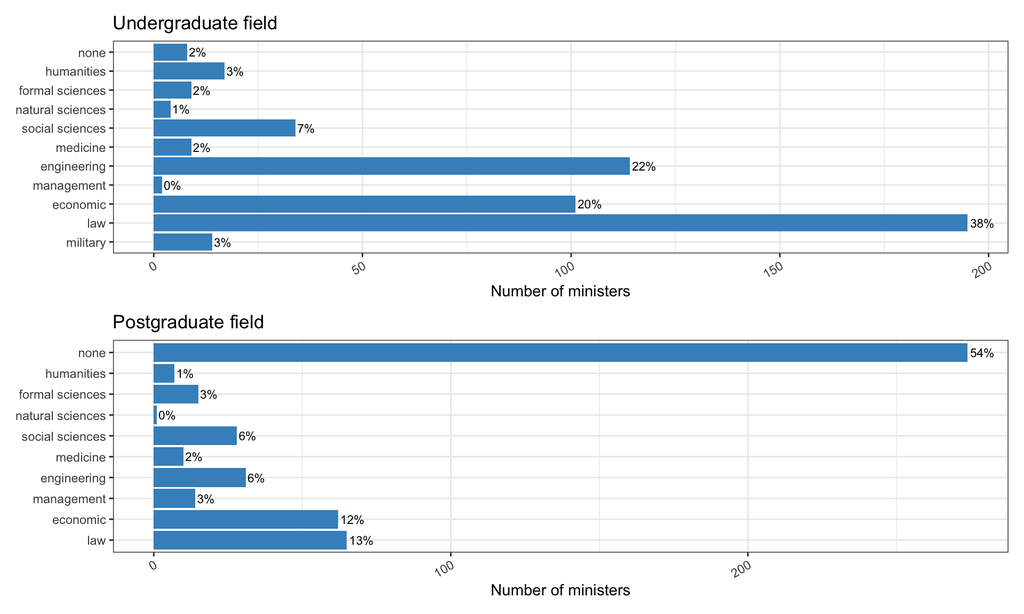

*Figure A2. Field of education, undergraduate and postgraduate (Portugal, ministerial appointments, N=507).*

At the undergraduate level, Law is by far the most common field of education (38.5%, 195/507), followed by Engineering (22.5%, 114/507) and Economics (19.9%, 101/507). Social Sciences (6.7%, 34/507), Humanities (3.4%, 17/507) and Military studies (2.8%, 14/507) are considerably less frequent, and Management is nearly absent as a first degree (0.4%, 2/507). Only 1.6% of ministers (8/507) report no undergraduate field.

At the postgraduate level, the dominant pattern is simply the absence of further education: 54.0% of ministers (274/507) hold no postgraduate degree at all. Among those who do, Law (12.8% of all ministers, 65/507) and Economics (12.2%, 62/507) remain the largest fields, followed by Engineering (6.1%, 31/507) and Social Sciences (5.5%, 28/507). Management, nearly absent at undergraduate level, becomes proportionally more present at postgraduate level (2.8%, 14/507, against 0.4% at undergraduate), consistent with management training being acquired mainly through postgraduate qualifications rather than as a first degree.

This is the level at which the existing literature typically stops: reporting which fields are more or less frequent among ministers, without asking whether those fields are actually relevant to the portfolios ministers go on to hold.

#### Figure A3: Field of education, by relation to the portfolio

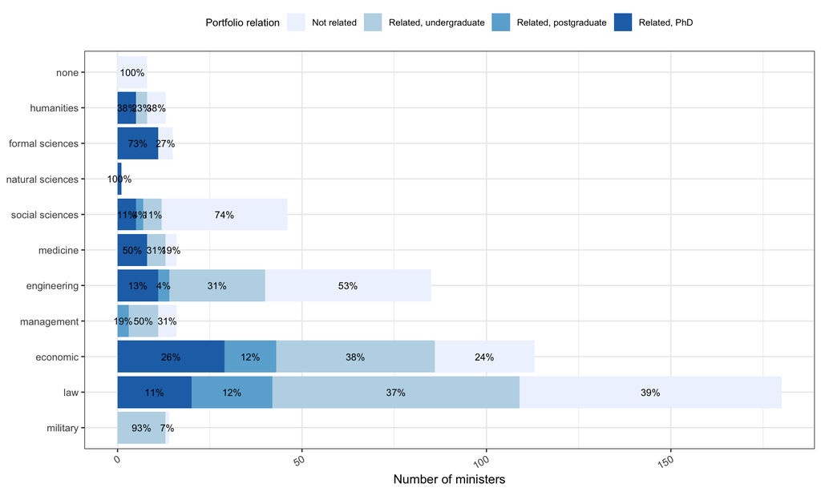

*Figure A3. Field of the highest degree attained, by relation to the portfolio (Portugal, ministerial appointments, N=507). Bars show the field of each minister’s highest educational qualification; segments show whether, and at which level, any of the minister’s education is related to the substantive area of their portfolio (graduate, postgraduate non-PhD, or PhD).*

Field of the highest degree, by relation to the portfolio: Military education remains the field most consistently tied to portfolio relevance, and now we can be precise about where: 92.9% of ministers with military as their highest field (13/14) show that relevance at the graduate level itself, with no cases at postgraduate or PhD level, consistent with military training as a single, self-contained qualification track.

Law and Economics continue to diverge sharply. Law shows 39.4% no relation (71/180), 37.2% related at graduate level (67/180), 12.2% at postgraduate non-PhD level (22/180), and 11.1% at PhD level (20/180); relatedness is spread fairly evenly across all three related tiers. Economics shows 23.9% no relation (27/113), 38.1% related at graduate level (43/113), only 12.4% at postgraduate non-PhD level (14/113), but 25.7% at PhD level (29/113), meaning that when an Economics background is related to the portfolio beyond the first degree, it is disproportionately a doctorate rather than a non-PhD postgraduate qualification.

The disaggregation is most informative for Medicine and Formal Sciences. What earlier appeared as postgraduate-level relatedness for these two fields turns out to be entirely PhD-driven: Medicine shows 0% at postgraduate non-PhD level and 50.0% at PhD level (8/16); Formal Sciences shows 0% at postgraduate non-PhD level and 73.3% at PhD level (11/15). In both fields, relatedness beyond the first degree is acquired exclusively through doctoral training, not through non-PhD postgraduate qualifications.

As an internal consistency check: the four column totals in A3 (203 not related, 170 related at graduate level, 44 related at postgraduate non-PhD level, 90 related at PhD level) match exactly the marginal distribution of edu_level_related reported for the full sample, and the 8 ministers with no field (“none”) are all classified as not related, consistent with the 8 secondary-only ministers identified in A1.

#### Figure A4: Academic dimension

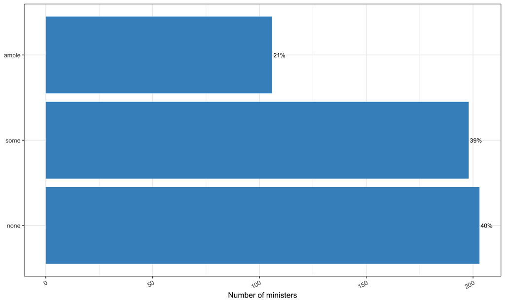

*Figure A4. Distribution of academic expertise (Portugal, ministerial appointments, N=507).*

The aggregated academic dimension distributes as follows: 40.0% of ministers (203/507) show no academic expertise, 39.1% (198/507) some, and 20.9% (106/507) ample. Read jointly with Figure A3, this trichotomous summary is consistent with the field-by-relatedness pattern already described: given that only 60.0% of ministers hold any portfolio-related education (Figure A1), and that among these a large share is related only at the graduate level, ample academic expertise, the top category of the scale, is reached by roughly one in five ministers, while a comparable share (40.0%) reaches none at all.

## Occupational Dimension

#### Figure A5: Prior occupation, by relation to the portfolio

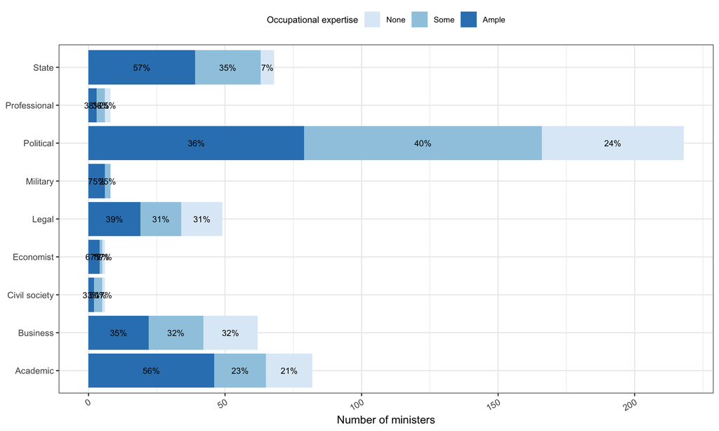

*Figure A5. Prior occupational background, by occupational expertise (Portugal, ministerial appointments, N=507). Bars show ministers’ occupational background prior to appointment, aggregated into nine career families (expertise_Job_type_agg); segments show the level of occupational expertise (expertise_Job: none/some/ample) associated with that background.*

Prior occupation: Political careers are by far the most common occupational background among Portuguese ministers (43.0%, 218/507), roughly two and a half times more frequent than the next largest category, Academic (16.2%, 82/507). State careers (13.4%, 68/507), Business (12.2%, 62/507) and Legal (9.7%, 49/507) form a middle tier, while Military and Professional backgrounds are each rare (1.6%, 8/507 each), and Civil society and Economist are the smallest categories (1.2%, 6/507 each).

Prior occupation, by relation to the portfolio: Crossing occupational background with occupational expertise shows that the most common pathway into ministerial office is not the one most likely to generate high occupational expertise. Political careers, despite accounting for 43.0% of all ministers, generate ample occupational expertise in only 36.2% of cases (79/218), with 39.9% reaching only some (87/218) and 23.9% none (52/218). By contrast, considerably less frequent backgrounds show markedly higher ample rates: State careers reach ample in 57.4% of cases (39/68), Academic careers in 56.1% (46/82), and Military careers in 75.0% (6/8, though this last figure rests on a very small N and should be read with caution). Economist shows the highest point estimate of all (66.7%, 4/6) but is based on only 6 cases.

Overall, across all 507 ministers, 22.3% show no occupational expertise (113), 34.3% some (174), and 43.4% ample (220). Political careers underperform this overall ample rate (36.2% vs. 43.4%), which is notable precisely because they are the modal pathway into office: the largest single route into the ministerial elite is not the one generating the highest levels of portfolio-relevant occupational expertise.

#### Figure A6: Occupational dimension

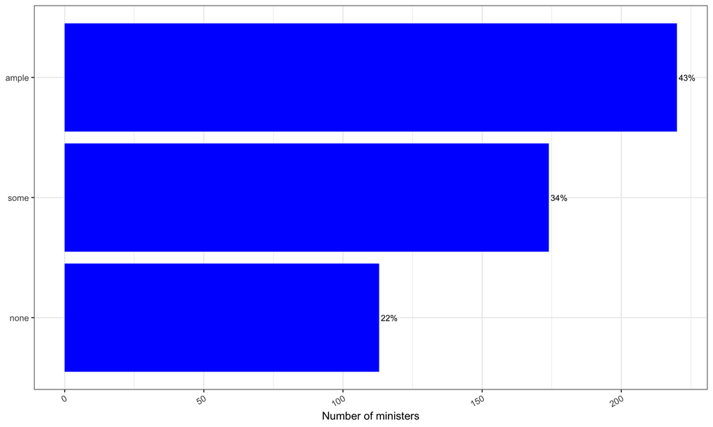

*Figure A6. Distribution of occupational expertise (Portugal, ministerial appointments, N=507).*

The aggregated occupational dimension shows 22.3% of ministers (113/507) with no occupational expertise, 34.3% (174/507) with some, and 43.4% (220/507) with ample, the highest ample share of the three dimensions. As already noted in relation to Figure A5, this overall distribution is not driven by the modal occupational background: political careers, which account for 43.0% of all ministers, generate ample occupational expertise in only 36.2% of cases, below the 43.4% ample rate for the sample as a whole.

## Managerial Dimension

#### Figure A7: Managerial experience sector

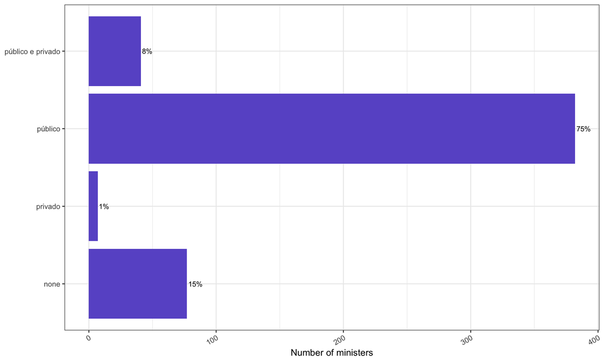

*Figure A7. Sector of prior managerial experience (Portugal, ministerial appointments, N=507).*

Prior managerial experience among Portuguese ministers is heavily concentrated in the public sector: 75.3% (382/507) held managerial experience exclusively in the public sector, compared to only 1.4% (7/507) exclusively in the private sector and 8.1% (41/507) in both sectors. A further 15.2% (77/507) report no prior managerial experience at all. This sectoral concentration mirrors the broader recruitment pattern already noted for occupational background (Figure A5), where political and state careers, both public-sector-anchored, together account for more than half of all ministers.

#### Figure A8: Managerial experience sector, by level of managerial expertise

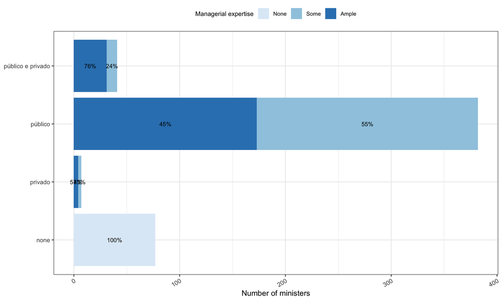

*Figure A8. Sector of managerial experience, by managerial expertise (Portugal, ministerial appointments, N=507).*

Crossing sector of managerial experience with the level of managerial expertise shows that experience in the public sector, and especially in both sectors combined, is what converts into higher managerial expertise. Among the 41 ministers with experience in both the public and private sectors, 75.6% (31/41) reach ample managerial expertise, the highest ample rate of any sector category. Ministers with public-sector-only experience reach ample in 45.3% of cases (173/382), close to the 41.0% ample rate for the sample as a whole (Figure A10), while the small group with private-sector-only experience splits between some (42.9%, 3/7) and ample (57.1%, 4/7). By construction, all 77 ministers with no prior managerial experience score none on the managerial dimension.

#### Figure A9: Occupational background, by managerial expertise

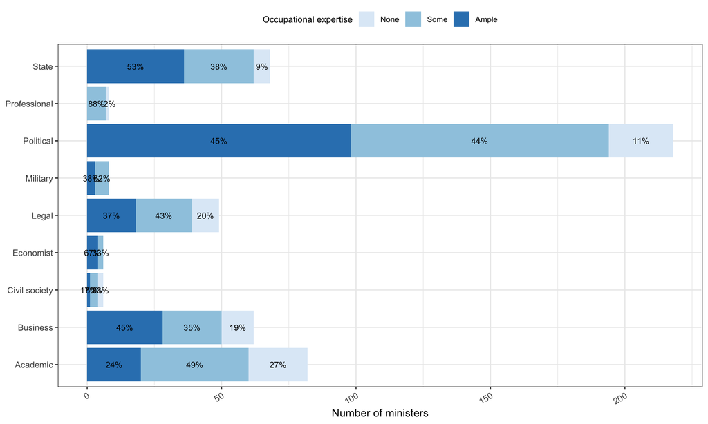

*Figure A9. Occupational background, by managerial expertise (Portugal, ministerial appointments, N=507).*

#### Figure A10: Managerial dimension

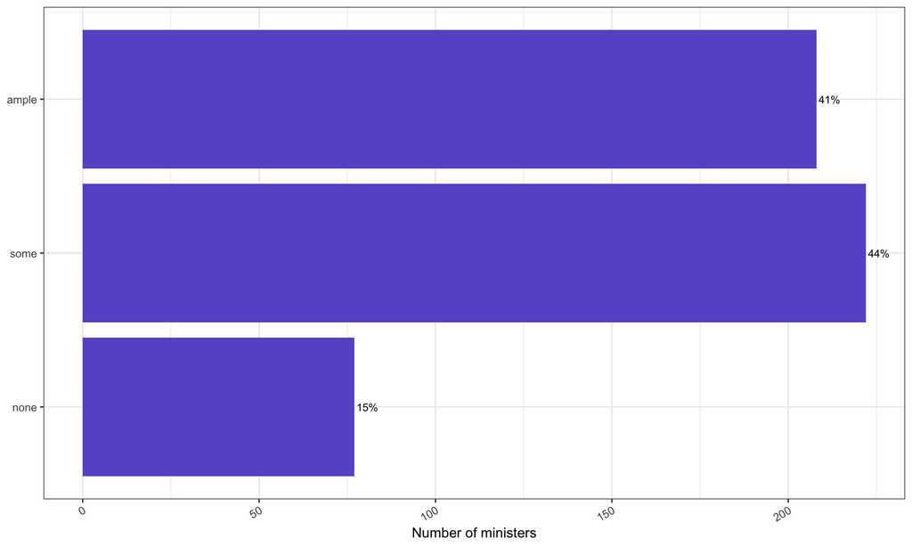

*Figure A10. Distribution of managerial expertise (Portugal, ministerial appointments, N=507).*

The aggregated managerial dimension shows 15.2% of ministers (77/507) with no managerial expertise, 43.8% (222/507) with some, and 41.0% (208/507) with ample. Of the three dimensions, managerial expertise has the lowest share at none (15.2%, against 22.3% for occupational and 40.0% for academic) and a substantial ample share (41.0%), only slightly below the 43.4% ample rate of the occupational dimension. As already shown in Figures A7 and A8, this reflects the near-universal (84.8%) prior managerial experience among Portuguese ministers, concentrated overwhelmingly in the public sector, and the fact that public-sector and mixed-sector experience convert into ample managerial expertise at comparatively high rates.

# II. Level B: Bivariate relations between dimensions

## Figure B1: Co-occurrence among academic, occupational, and managerial expertise

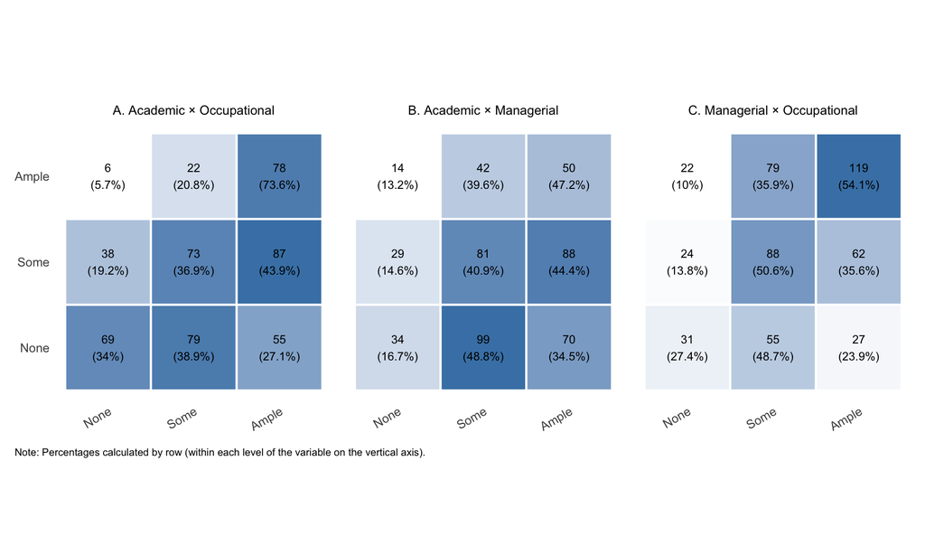

*Figure B1. Co-occurrence among academic, occupational, and managerial expertise (Portugal, ministerial appointments, N=507). Each panel cross-tabulates one pair of expertise dimensions; percentages are calculated by row, within each level of the dimension on the vertical axis.*

## Figure B2: Correlations among academic, occupational, and managerial expertise

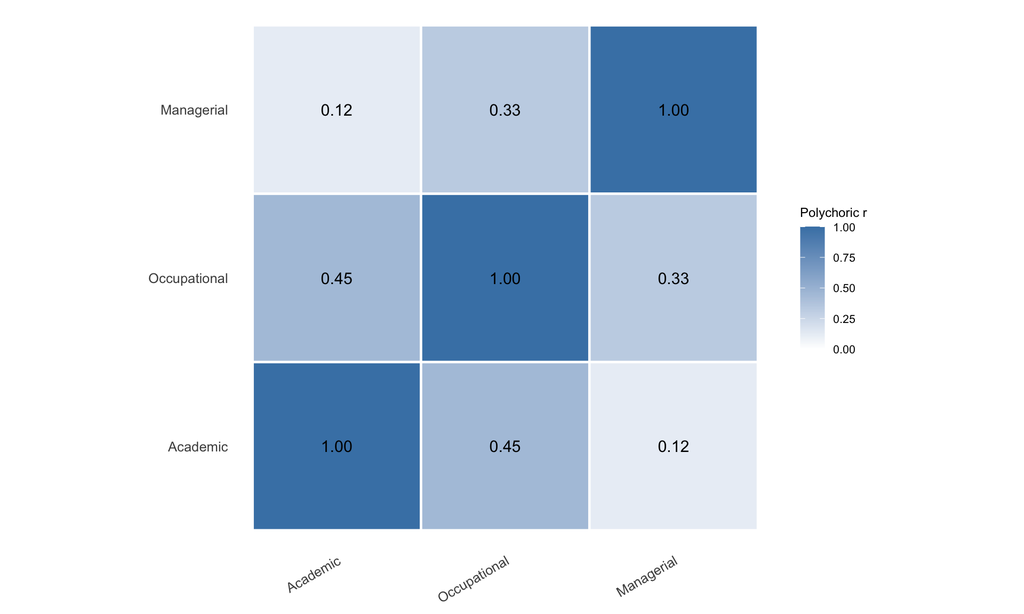

*Figure B2. Polychoric correlations among academic, occupational, and managerial expertise (Portugal, ministerial appointments, N=507).*

Academic-occupational. The polychoric correlation is moderate (r = 0.45), the strongest of the three pairs. The co-occurrence table shows a clear positive gradient: ample occupational expertise rises from 27.1% among ministers with no academic expertise to 43.9% (some) and 73.6% (ample). The association is real but far from a substitution: 27.1% of ministers with no academic expertise still reach ample occupational expertise, and 5.7% of ministers with ample academic expertise remain at none on the occupational side. The two dimensions correlate, but neither is reducible to the other.

Academic-managerial. The polychoric correlation is weak (r = 0.12), the weakest of the three pairs. The co-occurrence table is comparatively flat: ample managerial expertise rises only modestly across academic levels (34.5%, 44.4%, 47.2%), and the share with no managerial expertise barely moves (16.7%, 14.6%, 13.2%). Academic and managerial expertise behave as largely independent, distinct forms of competence, consistent with managerial expertise’s transversal, non-domain-specific character (Paper 1).

Occupational-managerial. The polychoric correlation is moderate (r = 0.33), between the other two pairs. Ample managerial expertise rises from 23.9% (no occupational expertise) to 35.6% (some) and 54.1% (ample), while the share with no managerial expertise falls from 27.4% to 10.0% over the same range. The association is closer than academic-managerial but still leaves substantial independent variation.

Across the three pairs, the pattern is one of moderate and uneven association, not full redundancy or full independence: strongest between academic and occupational expertise, weakest between academic and managerial, intermediate between occupational and managerial. This does not support treating educational and occupational credentials as interchangeable proxies for a single construct, nor does it support treating managerial expertise as redundant with the other two.

As an internal consistency check: the row totals in both t_AcaJob and t_AcaManag (203 none, 198 some, 106 ample) match each other, since both share the same Academic marginal; and the row totals in t_JobManag (113 none, 174 some, 220 ample) match exactly the overall occupational expertise distribution already reported in A6.

# Level C: Joint structure of the three dimensions

## Figure C1: Multidimensionality of the expertise space (Eigenvalues)

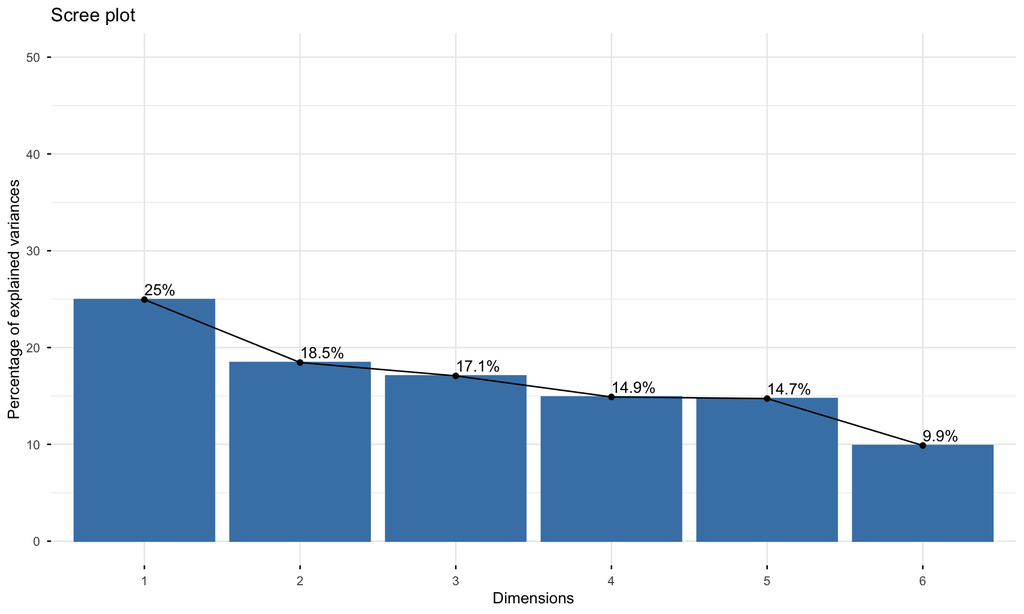

*Figure C1. Eigenvalues / percentage of inertia by axis, MCA of academic, occupational, and managerial expertise (Portugal, ministerial appointments, N=507).*

The first axis accounts for only 24.96% of total inertia, far short of what a single dominant dimension would require. The remaining axes decline gradually rather than dropping off sharply: 18.45%, 17.08%, 14.90%, 14.73%, and 9.88%. Four axes are needed to reach 75.4% of total inertia. If academic, occupational, and managerial expertise were redundant, collapsible onto one latent trait, the first axis would concentrate most of the inertia and the rest would be negligible; instead, inertia is distributed fairly evenly across several axes. This directly tests, and does not support, the assumption built into unidimensional or additive indices: the expertise space is genuinely multidimensional, not reducible to a single technocratic gradient.

## Figure C2: Dimensional structure of the axes (eta²)

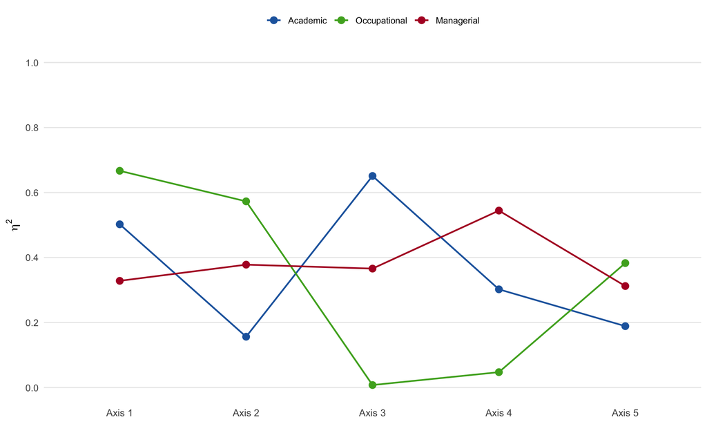

*Figure C2. Association (η²) between each expertise dimension and each MCA axis (Portugal, ministerial appointments, N=507). Axis n corresponds to MCA Dimension n; terminology follows the program convention (see glossary).*

Each axis is structured by a different dominant dimension, and the pattern sharpens as one moves past the first axis. Axis 1 combines occupational (η² = 0.67) and academic (η² = 0.50) expertise, a general gradient of accumulation, with managerial contributing more moderately (η² = 0.33). Axis 2 is occupational-specific (η² = 0.57), with managerial secondary (η² = 0.38) and academic weak (η² = 0.16). Axis 3 is academic-specific (η² = 0.65) and essentially orthogonal to occupational (η² = 0.01), the clearest case of dimensional separation in the whole space. Axis 4 is managerial-specific (η² = 0.54), with occupational nearly absent (η² = 0.05). Axis 5 is more mixed, with moderate loadings from all three (Job = 0.38, Manag = 0.31, Acad = 0.19), consistent with a residual axis. Taken together, each of the three dimensions has at least one axis on which it dominates and on which the others are weak or negligible, evidence that academic, occupational, and managerial expertise are not collapsing into one another even where they share a common general axis.

## Configurations of expertise (clusters)

### Step 1: Automatic (data-driven) solution

#### Figure C3: Cluster sizes (automatic solution)

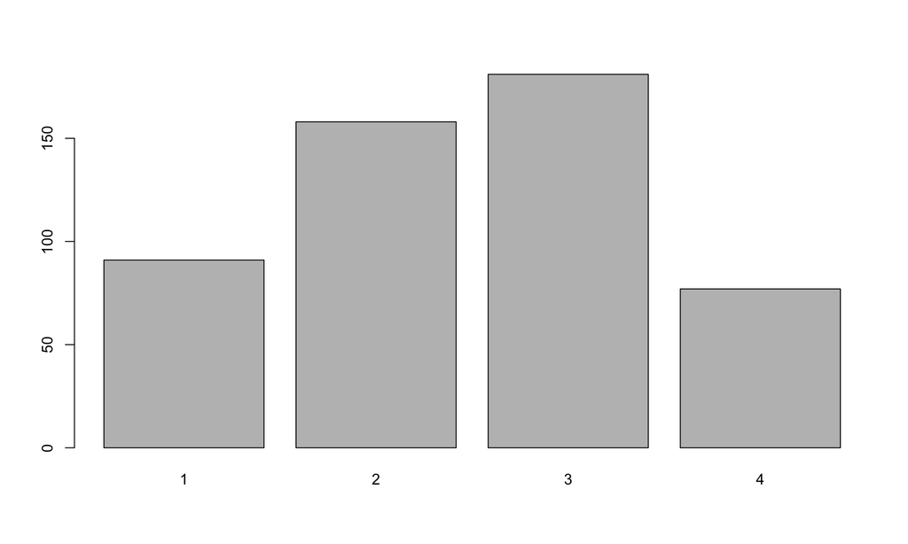

*Figure C3. Size of the clusters retained by the automatic (data-driven) HCPC solution (Portugal, ministerial appointments, N=507).*

The automatic criterion selects a 4-cluster solution: 91 (17.9%), 158 (31.2%), 181 (35.7%), and 77 (15.2%) ministers. This unconstrained solution is the baseline against which any theoretically motivated alternative is evaluated.

### Steps 2 & 3 — Data Manager task only (theory-driven alternative, if applicable)

```
            TestClusters
AutoClusters   1   2   3   4   5 Sum
         1    91   0   0   0   0  91
         2     0 158   0   0   0 158
         3     0   0  81   0 100 181
         4     0   0   0  77   0  77
         Sum  91 158  81  77 100 507
```

```
clusterK
  1   2   3   4   5
 91 158  81  77 100
```

```
clusterK
    1     2     3     4     5   Sum
 17.9  31.2  16.0  15.2  19.7 100.0
```

### Step 4: Cluster profiles by expertise dimension

#### Figure C4: Cluster profile, by expertise dimension

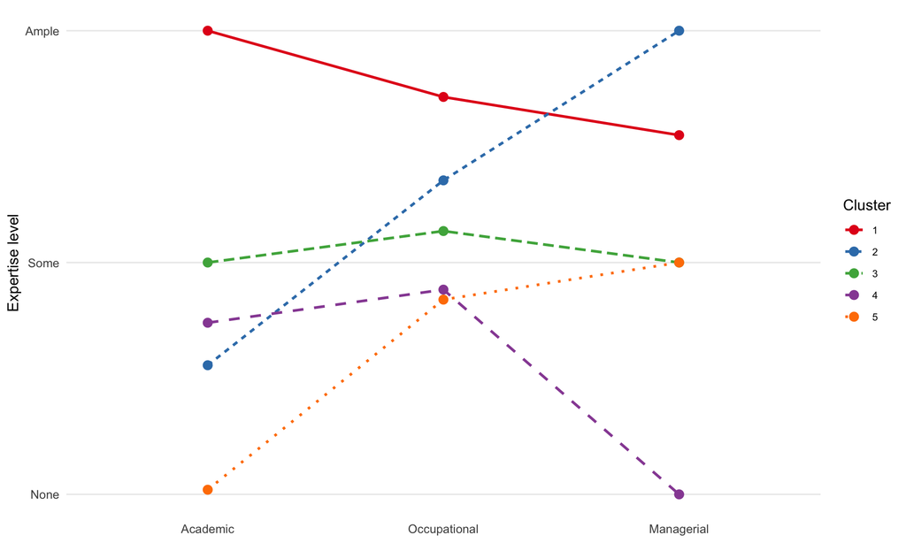

*Figure C4. Mean expertise level per dimension, by cluster (Portugal, ministerial appointments, N=507). Clusters identified by number only; substantive labels are assigned in Step 5, after inspecting this profile.*

The mean score on each dimension (1 = none, 2 = some, 3 = ample) defines each cluster substantively. C1 Polivalent Experts (N=91, 17.9%) is high on all three dimensions (Academic 3.00, Occupational 2.71, Managerial 2.55), the only cluster strong across the board. C2 Executive Politicians (N=158, 31.2%, the largest cluster) is dominated by managerial expertise (3.00, the maximum), with occupational moderately high (2.35) and academic the weakest of the three (1.56). C3 Political Generalists (N=81, 16.0%) is flat and moderate across all three dimensions (2.00, 2.14, 2.00), with no dimension standing out. C4 Academic Specialists (N=77, 15.2%) is defined less by academic strength in absolute terms (1.74, actually slightly below occupational at 1.88) than by the near-total absence of managerial expertise (1.00, the floor: every minister in this cluster scores none on managerial); relative to that floor, academic and occupational are the retained dimensions, hence the label. C5 Generalist Politicians (N=100, 19.7%) is the mirror case of low academic expertise (1.02, essentially floor), with occupational (1.84) and managerial (2.00) both moderate.

No single configuration dominates the ministerial population: the largest cluster accounts for less than a third of cases, and the other four range narrowly between 15% and 20%. This plurality would not be visible under a unidimensional or additive index, which by construction produces a single ranked continuum rather than discrete, qualitatively distinct configurations. The recurrence of clusters combining high managerial with low academic (C2), and low managerial with modest academic and occupational (C4), in particular, shows configurations that a “more expertise is always better” index would score similarly, low or middling, while in fact they represent qualitatively different resource profiles.

### Step 5: Cluster labeling — Data Manager task only (after Figure C4 is interpreted)

### Appendix: validation and composition (tables supplementary to Figure C4)

C1 Polivalent Experts is built entirely from logical types that include ample academic expertise: pure academic (13.2%), academic-occupational (31.9%), academic-managerial (11.0%), and integrated expertise, ample on all three (44.0%, nearly half the cluster). No minister in this cluster falls outside these four academic-anchored types.

C2 Executive Politicians splits exactly between the two logical types that include ample managerial expertise: pure managerial (50.0%) and occupational-managerial (50.0%). Every minister in this cluster has ample managerial expertise; the cluster differs internally only in whether occupational expertise also reaches ample.

Two conclusions follow. First, the empirical typology recovers the structure predicted by the logical typology: clusters anchored in academic ample (C1) and managerial ample (C2) map cleanly onto the corresponding logical types, external validation of the clustering solution. Second, the empirical typology adds resolution that the logical typology, built only from ample/not-ample thresholds, cannot provide on its own: three of the five clusters (C3, C4, C5) fall largely within the single residual category “partial expertise,” yet MCA and HCPC differentiate them clearly: a flat, moderate profile (C3), a profile anchored in the absence of managerial expertise (C4), and a profile anchored in the absence of academic expertise (C5). This is precisely the descriptive gain a graduated, multidimensional measure offers over a binary or purely deductive one.